# Ames Housing Saleprice dataset Analysis - Capstone Project

Dhivya Subramaniam

November 28, 2016

# Introduction

Home values, prices and sales showed some of their strongest numbers since before the economic downturn a few years ago.Mortgage rates were downright cheap.

But there’s no guarantee favorable conditions for buying and borrowing will continue in the months ahead.

Consequently, it’s fair to ask the question: Can we predict housing prices with the help of some of the features in the Ames House pricing dataset?

Industry experts weigh in. Though no one can tell the future, their housing market forecast can help first-time home buyers make better decisions this year and next.

# Data Exploration of Ames Housing Sales price Dataset

Number of records (Train set: 1460, Test set: 1459)

1. Data Type differences between Train data set and Test data set

Datatype differs for some of the columns between Train data set and Test data set, Example Garage Area is Numeric type in Train data set where as String in Test data set due to NA values. Handled data type differences using Edit Meta data Module and Apply SQL Transformation module in Azure ML.

2. Missing values in Train data set

Below fields have minimum missing values that may add value or reduce errors in predicticting sales price. Lot Frontage(numeric) : 259 missing values Masvnrtype(string):8 missing values Masvnrarea(numeric) :8 missing values Electrical(string) : 1 missing value Garage Type(string): 81 missing values Garage Yrblt(string) : 81 missing values Garage area(numeric): 81 missing values Garage cars(numeric) : 81 missing values

Below fields has huge missing values and that will not add any values to predict sales price.

Alley(string) : 1369 missing values PoolQc(string) :1453 missing values fence(string):1179 missing values miscfeature(strng) : 1406 missing valuess

Missing values are handled using convert to dataset module with replace custom option NA to 0 for Numeric and NA to None for string.

3. Need to replace outliers ( I chose to replace with 95th percentile of data in each selected feature)

## Initial set up in R

```r
# Clear workspace and console

rm(list=ls())
cat("\014")
```

```r
# Setting the working directory

setwd("D:/Users/dhsubram/Desktop/Back up folder/my folder/DataScience/R_Project")


# Install required packages and add library

#install.packages('rmarkdown')
#install.packages('plotly')
#if(!require("glmnet", quietly = TRUE)) install.packages("glmnet")
#if(!require("kernlab", quietly = TRUE)) install.packages("kernlab")
library(glmnet)
library(caret)
library(car)
library(nortest)
library(MASS)
library(randomForest)
library(mlbench)
library(kernlab)
```

## Read the data and take a look at a few records

```r
#Load the data

dataset1_train <- read.csv("train.csv")
names(dataset1_train)
```

```
##  [1] "Id"            "MSSubClass"    "MSZoning"      "LotFrontage"
##  [5] "LotArea"       "Street"        "Alley"         "LotShape"
##  [9] "LandContour"   "Utilities"     "LotConfig"     "LandSlope"
## [13] "Neighborhood"  "Condition1"    "Condition2"    "BldgType"
## [17] "HouseStyle"    "OverallQual"   "OverallCond"   "YearBuilt"
## [21] "YearRemodAdd"  "RoofStyle"     "RoofMatl"      "Exterior1st"
## [25] "Exterior2nd"   "MasVnrType"    "MasVnrArea"    "ExterQual"
## [29] "ExterCond"     "Foundation"    "BsmtQual"      "BsmtCond"
## [33] "BsmtExposure"  "BsmtFinType1"  "BsmtFinSF1"    "BsmtFinType2"
## [37] "BsmtFinSF2"    "BsmtUnfSF"     "TotalBsmtSF"   "Heating"
## [41] "HeatingQC"     "CentralAir"    "Electrical"    "X1stFlrSF"
## [45] "X2ndFlrSF"     "LowQualFinSF"  "GrLivArea"     "BsmtFullBath"
## [49] "BsmtHalfBath"  "FullBath"      "HalfBath"      "BedroomAbvGr"
## [53] "KitchenAbvGr"  "KitchenQual"   "TotRmsAbvGrd"  "Functional"
## [57] "Fireplaces"    "FireplaceQu"   "GarageType"    "GarageYrBlt"
## [61] "GarageFinish"  "GarageCars"    "GarageArea"    "GarageQual"
## [65] "GarageCond"    "PavedDrive"    "WoodDeckSF"    "OpenPorchSF"
## [69] "EnclosedPorch" "X3SsnPorch"    "ScreenPorch"   "PoolArea"
## [73] "PoolQC"        "Fence"         "MiscFeature"   "MiscVal"
## [77] "MoSold"        "YrSold"        "SaleType"      "SaleCondition"
## [81] "SalePrice"
```

```r
nrow(dataset1_train)
```

```
## [1] 1460
```

```r
ncol(dataset1_train)
```

```
## [1] 81
```

```r
dataset2_test <- read.csv("test.csv")
names(dataset2_test)
```

```
##  [1] "Id"            "MSSubClass"    "MSZoning"      "LotFrontage"
##  [5] "LotArea"       "Street"        "Alley"         "LotShape"
##  [9] "LandContour"   "Utilities"     "LotConfig"     "LandSlope"
## [13] "Neighborhood"  "Condition1"    "Condition2"    "BldgType"
## [17] "HouseStyle"    "OverallQual"   "OverallCond"   "YearBuilt"
## [21] "YearRemodAdd"  "RoofStyle"     "RoofMatl"      "Exterior1st"
## [25] "Exterior2nd"   "MasVnrType"    "MasVnrArea"    "ExterQual"
## [29] "ExterCond"     "Foundation"    "BsmtQual"      "BsmtCond"
## [33] "BsmtExposure"  "BsmtFinType1"  "BsmtFinSF1"    "BsmtFinType2"
## [37] "BsmtFinSF2"    "BsmtUnfSF"     "TotalBsmtSF"   "Heating"
## [41] "HeatingQC"     "CentralAir"    "Electrical"    "X1stFlrSF"
## [45] "X2ndFlrSF"     "LowQualFinSF"  "GrLivArea"     "BsmtFullBath"
## [49] "BsmtHalfBath"  "FullBath"      "HalfBath"      "BedroomAbvGr"
## [53] "KitchenAbvGr"  "KitchenQual"   "TotRmsAbvGrd"  "Functional"
## [57] "Fireplaces"    "FireplaceQu"   "GarageType"    "GarageYrBlt"
## [61] "GarageFinish"  "GarageCars"    "GarageArea"    "GarageQual"
## [65] "GarageCond"    "PavedDrive"    "WoodDeckSF"    "OpenPorchSF"
## [69] "EnclosedPorch" "X3SsnPorch"    "ScreenPorch"   "PoolArea"
## [73] "PoolQC"        "Fence"         "MiscFeature"   "MiscVal"
## [77] "MoSold"        "YrSold"        "SaleType"      "SaleCondition"
```

```r
nrow(dataset2_test)
```

```
## [1] 1459
```

```r
ncol(dataset2_test)
```

```
## [1] 80
```

```r
## Summary statistics
summary(dataset1_train)
```

```
##        Id           MSSubClass       MSZoning     LotFrontage
##  Min.   :   1.0   Min.   : 20.0   C (all):  10   Min.   : 21.00
##  1st Qu.: 365.8   1st Qu.: 20.0   FV     :  65   1st Qu.: 59.00
##  Median : 730.5   Median : 50.0   RH     :  16   Median : 69.00
##  Mean   : 730.5   Mean   : 56.9   RL     :1151   Mean   : 70.05
##  3rd Qu.:1095.2   3rd Qu.: 70.0   RM     : 218   3rd Qu.: 80.00
##  Max.   :1460.0   Max.   :190.0                  Max.   :313.00
##                                                  NA's   :259
##     LotArea        Street      Alley      LotShape  LandContour
##  Min.   :  1300   Grvl:   6   Grvl:  50   IR1:484   Bnk:  63
##  1st Qu.:  7554   Pave:1454   Pave:  41   IR2: 41   HLS:  50
##  Median :  9478               NA's:1369   IR3: 10   Low:  36
##  Mean   : 10517                           Reg:925   Lvl:1311
##  3rd Qu.: 11602
##  Max.   :215245
##
##   Utilities      LotConfig    LandSlope   Neighborhood   Condition1
##  AllPub:1459   Corner : 263   Gtl:1382   NAmes  :225   Norm   :1260
##  NoSeWa:   1   CulDSac:  94   Mod:  65   CollgCr:150   Feedr  :  81
##                FR2    :  47   Sev:  13   OldTown:113   Artery :  48
##                FR3    :   4              Edwards:100   RRAn   :  26
##                Inside :1052              Somerst: 86   PosN   :  19
##                                          Gilbert: 79   RRAe   :  11
##                                          (Other):707   (Other):  15
##    Condition2     BldgType      HouseStyle   OverallQual
##  Norm   :1445   1Fam  :1220   1Story :726   Min.   : 1.000
##  Feedr  :   6   2fmCon:  31   2Story :445   1st Qu.: 5.000
##  Artery :   2   Duplex:  52   1.5Fin :154   Median : 6.000
##  PosN   :   2   Twnhs :  43   SLvl   : 65   Mean   : 6.099
##  RRNn   :   2   TwnhsE: 114   SFoyer : 37   3rd Qu.: 7.000
##  PosA   :   1                 1.5Unf : 14   Max.   :10.000
##  (Other):   2                 (Other): 19
##   OverallCond      YearBuilt     YearRemodAdd    RoofStyle
##  Min.   :1.000   Min.   :1872   Min.   :1950   Flat   :  13
##  1st Qu.:5.000   1st Qu.:1954   1st Qu.:1967   Gable  :1141
##  Median :5.000   Median :1973   Median :1994   Gambrel:  11
##  Mean   :5.575   Mean   :1971   Mean   :1985   Hip    : 286
##  3rd Qu.:6.000   3rd Qu.:2000   3rd Qu.:2004   Mansard:   7
##  Max.   :9.000   Max.   :2010   Max.   :2010   Shed   :   2
##
```

[output cut: 89 more lines]

```
##  GdPrv:  59   Gar2:   2   Min.   :    0.00   Min.   : 1.000
##  GdWo :  54   Othr:   2   1st Qu.:    0.00   1st Qu.: 5.000
##  MnPrv: 157   Shed:  49   Median :    0.00   Median : 6.000
##  MnWw :  11   TenC:   1   Mean   :   43.49   Mean   : 6.322
##  NA's :1179   NA's:1406   3rd Qu.:    0.00   3rd Qu.: 8.000
##                           Max.   :15500.00   Max.   :12.000
##
##      YrSold        SaleType    SaleCondition    SalePrice
##  Min.   :2006   WD     :1267   Abnorml: 101   Min.   : 34900
##  1st Qu.:2007   New    : 122   AdjLand:   4   1st Qu.:129975
##  Median :2008   COD    :  43   Alloca :  12   Median :163000
##  Mean   :2008   ConLD  :   9   Family :  20   Mean   :180921
##  3rd Qu.:2009   ConLI  :   5   Normal :1198   3rd Qu.:214000
##  Max.   :2010   ConLw  :   5   Partial: 125   Max.   :755000
##                 (Other):   9
```

Feature Selection is performed in AzureML using FilterbasedFeature selection module. Top features selected in Azure ML with good score are provided below OverallQual , Neighborhood , GrLivArea , ExterQual , BsmtQual,KitchenQual,GarageArea, GarageYrBlt,MasVnrArea, TotalBsmtSF,LotArea, YearBlt and Yearremodelled,

OverallCond, Bedroomabvgr scores are less compared to above features but still added in the model to see if it can remove errors.

Selected below features based on Correlation analysis with SalePrice

OverallQual , Neighborhood, GrLivArea, ExterQual, LotFrontage, MasVnrArea, GarageYrBlt, BedroomAbvGr ,LotArea ,Overallcond, TotalBsmtSF and Age.

Age of the building is derived from YrSold, YearBlt and YrRemodelled.

Reference for Age is from Kaggle, Except Age rest all based on Correlation Analysis, Step AIC and Filter based Feature selection Module in Azure ML.

https://www.kaggle.com/mariopasquato/house-prices-advanced-regression-techniques/simplemodel

# clean up the data , remove NA in the dataset and replace outlier wiht 95th percentile

```r
# Convert below variables NA to 0 and make it as Integer in both Train and Test data


dataset1_train[(is.na(dataset1_train[,'LotFrontage'])),'LotFrontage']<- 0
dataset1_train[(is.na(dataset1_train[,'MasVnrArea'])),'MasVnrArea']<- 0
dataset1_train[(is.na(dataset1_train[,'GarageYrBlt'])),'GarageYrBlt']<- 0

dataset2_test[(is.na(dataset2_test[,'LotFrontage'])),'LotFrontage']<- 0
dataset2_test[(is.na(dataset2_test[,'MasVnrArea'])),'MasVnrArea']<- 0
dataset2_test[(is.na(dataset2_test[,'GarageYrBlt'])),'GarageYrBlt']<- 0


# Normalising Training Dataset

LogPrice <- log10(dataset1_train$SalePrice)
LogLotArea <- log10(dataset1_train$LotArea)
LogArea <- log10(dataset1_train$GrLivArea)
Bedroom <- dataset1_train$BedroomAbvGr
OverallCondition <- dataset1_train$OverallCond
External_Quality <- as.factor(dataset1_train$ExterQual)
Garage_area <- (dataset1_train$GarageArea)
bsmt_area <- (dataset1_train$TotalBsmtSF)
Age <- dataset1_train$YrSold - pmax(dataset1_train$YearBuilt,dataset1_train$YearRemodAdd)
Quality <- dataset1_train$OverallQual
Neighborhood <- as.factor(dataset1_train$Neighborhood)

# Replace Outlier in Train dataset with 95th percentile

Replace_outlier <- function(x){
  quantiles <- quantile( x, c(.95 ) )
  x[ x > quantiles[1] ] <- quantiles[1]
  x
}

LogLotArea <- Replace_outlier(LogLotArea)
Bedroom <- Replace_outlier(Bedroom)
OverallCondition <- Replace_outlier(OverallCondition)
LogArea <- Replace_outlier(LogArea)
Age <- Replace_outlier(Age)
Quality <- Replace_outlier(Quality)
LogPrice <- Replace_outlier(LogPrice)
Garage_area <- Replace_outlier(Garage_area)
bsmt_area <- Replace_outlier(bsmt_area)

# Move the data in to data frame

data_set_train=data.frame(LogLotArea,Bedroom,OverallCondition,External_Quality,LogArea,Age,Quality,Neighborhood,LogPrice,Garage_area,bsmt_area)

# Normalising Testing Dataset


LogLotArea <- log10(dataset2_test$LotArea)
LogArea <- log10(dataset2_test$GrLivArea)
Bedroom <- dataset2_test$BedroomAbvGr
OverallCondition <- dataset2_test$OverallCond
External_Quality <- as.factor(dataset2_test$ExterQual)
Garage_area <- (dataset2_test$GarageArea)
bsmt_area <- (dataset2_test$TotalBsmtSF)
Age <- dataset2_test$YrSold - pmax(dataset2_test$YearBuilt,dataset2_test$YearRemodAdd)
Quality <- dataset2_test$OverallQual
Neighborhood <- as.factor(dataset2_test$Neighborhood)

# Move data in to test data set frame.

data_set_test=data.frame(LogLotArea,Bedroom,OverallCondition,External_Quality,
                         LogArea,Age,Quality,Neighborhood,Garage_area,bsmt_area)
```

## Plotting Histogram to check the Normality

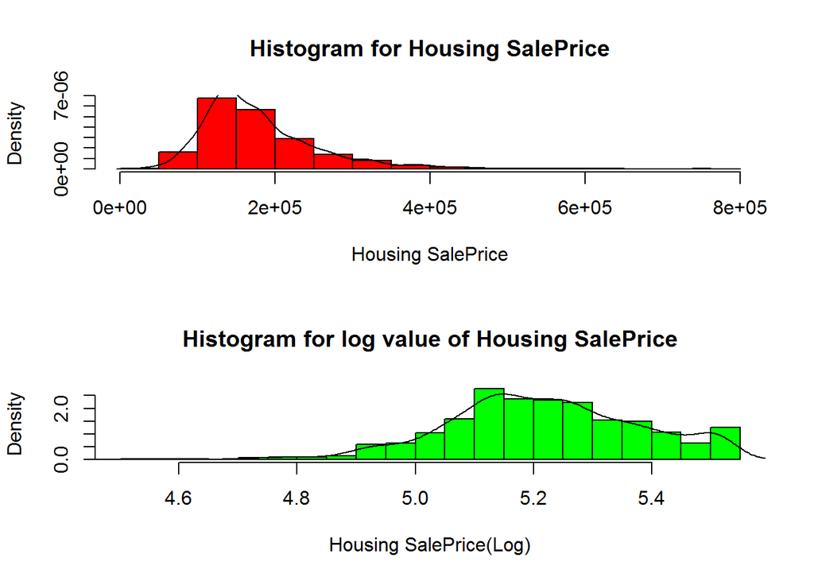

```r
# Check with the Histogram for SalePrice and log10 (SalePrice) Normality

par(mfrow = c(2,1))

hist(dataset1_train$SalePrice,breaks=20, freq=FALSE, main='Histogram for Housing SalePrice',xlab = 'Housing SalePrice',col="red")
lines(density(dataset1_train$SalePrice))
hist(LogPrice,breaks=20, freq=FALSE,main='Histogram for log value of Housing SalePrice',xlab = 'Housing SalePrice(Log)',col="green")
lines(density(LogPrice))
```

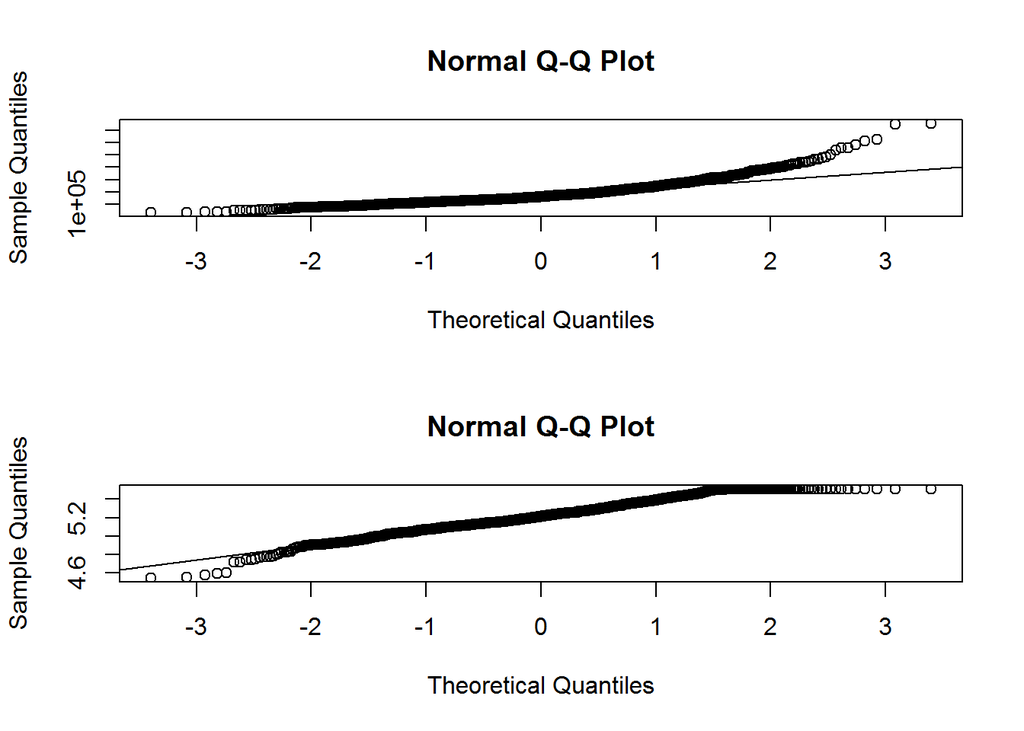

```r
par(mfrow = c(1,1))

# Normal QQ Plot

par(mfrow = c(2,1))

qqnorm(dataset1_train$SalePrice)
qqline(dataset1_train$SalePrice)

qqnorm(LogPrice)
qqline(LogPrice)
```

```r
par(mfrow = c(1,1))
```

After Normalising the SalePrice to log10(salePrice), Normality histogram and QQ Plots looks better hence will use the Log10(SalePrice) for our analysis.

## Plot the correlations

Let us will look at the correlations between the variables. The following display shows these correlations.

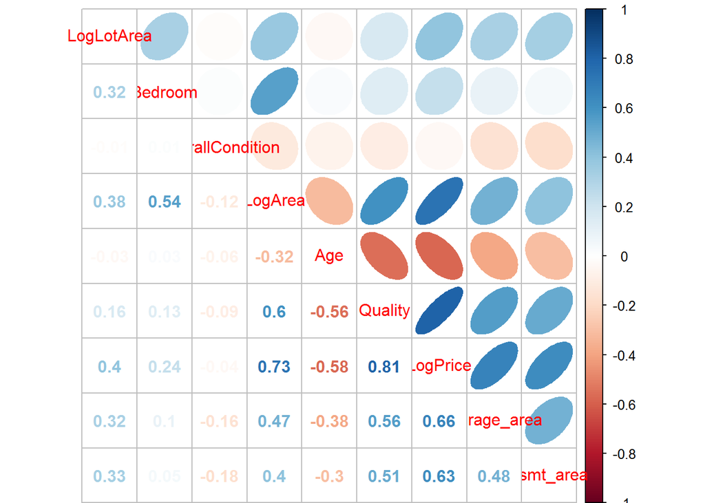

```r
cols <- c("LogLotArea","Bedroom","OverallCondition","LogArea","Age","Quality",
                    "LogPrice","Garage_area","bsmt_area")
cors = cor(data_set_train[, cols], method = 'pearson')
## Loading required package: corrplot
require(corrplot)

corrplot.mixed(cors, upper = "ellipse")
```

According to the plots,

Log(SalePrice) is positively correlated to Quality,LogArea,Bedroom, Lot area, GarageArea and Bsmt_area.

SalePrice is Negatively correlated to Age (derived from YrSold, YrBlt and Yr Remodelled)

No Correlation with OverallCondition

# Split the train dataset for 70% training the model and 30% testing the model

```r
## Split the training dataset to train and test the model to compare actual vs predicted

set.seed(123)
smp_size <- floor(0.70 * nrow(data_set_train))
Data_split <- sample(seq_len(nrow(data_set_train)), size = smp_size)

dataset1_trainingData <- data_set_train[Data_split, ]
dataset1_testingData <- data_set_train[-Data_split, ]
```

# Create Linear Model

```r
lm.model.1 = lm(LogPrice ~ LogLotArea+Bedroom+OverallCondition+External_Quality+LogArea+Age+Quality
                +Neighborhood+Garage_area+bsmt_area,  data = dataset1_trainingData)

summary(lm.model.1)
```

```
##
## Call:
## lm(formula = LogPrice ~ LogLotArea + Bedroom + OverallCondition +
##     External_Quality + LogArea + Age + Quality + Neighborhood +
##     Garage_area + bsmt_area, data = dataset1_trainingData)
##
## Residuals:
##      Min       1Q   Median       3Q      Max
## -0.33425 -0.02599  0.00314  0.03342  0.17324
##
## Coefficients:
##                       Estimate Std. Error t value Pr(>|t|)
## (Intercept)          3.362e+00  7.793e-02  43.139  < 2e-16 ***
## LogLotArea           8.026e-02  1.438e-02   5.582 3.08e-08 ***
## Bedroom             -7.935e-03  3.339e-03  -2.376 0.017669 *
## OverallCondition     2.133e-02  2.003e-03  10.649  < 2e-16 ***
## External_QualityFa  -2.651e-02  2.398e-02  -1.106 0.269185
## External_QualityGd  -1.304e-02  1.095e-02  -1.191 0.233990
## External_QualityTA  -1.846e-02  1.232e-02  -1.499 0.134134
## LogArea              3.842e-01  2.274e-02  16.895  < 2e-16 ***
## Age                 -7.957e-04  1.291e-04  -6.165 1.03e-09 ***
## Quality              2.770e-02  2.498e-03  11.088  < 2e-16 ***
## NeighborhoodBlueste -1.913e-02  4.339e-02  -0.441 0.659424
## NeighborhoodBrDale  -6.296e-02  2.306e-02  -2.730 0.006438 **
## NeighborhoodBrkSide -6.870e-02  1.973e-02  -3.482 0.000519 ***
## NeighborhoodClearCr  1.778e-02  2.173e-02   0.818 0.413334
## NeighborhoodCollgCr -2.747e-03  1.736e-02  -0.158 0.874331
## NeighborhoodCrawfor  2.014e-03  1.983e-02   0.102 0.919100
## NeighborhoodEdwards -5.727e-02  1.857e-02  -3.084 0.002097 **
## NeighborhoodGilbert  2.573e-03  1.873e-02   0.137 0.890758
## NeighborhoodIDOTRR  -1.406e-01  2.106e-02  -6.676 4.09e-11 ***
## NeighborhoodMeadowV -4.849e-02  2.715e-02  -1.786 0.074368 .
## NeighborhoodMitchel -3.574e-02  2.016e-02  -1.773 0.076534 .
## NeighborhoodNAmes   -4.030e-02  1.823e-02  -2.211 0.027271 *
## NeighborhoodNoRidge  2.941e-02  1.986e-02   1.481 0.138983
## NeighborhoodNPkVill -1.199e-02  2.576e-02  -0.466 0.641655
## NeighborhoodNridgHt  2.252e-02  1.810e-02   1.244 0.213649
## NeighborhoodNWAmes  -4.079e-02  1.919e-02  -2.126 0.033744 *
## NeighborhoodOldTown -1.158e-01  1.844e-02  -6.281 5.04e-10 ***
## NeighborhoodSawyer  -5.077e-02  1.960e-02  -2.590 0.009735 **
## NeighborhoodSawyerW -1.269e-02  1.856e-02  -0.684 0.494234
## NeighborhoodSomerst  2.485e-02  1.733e-02   1.434 0.151856
## NeighborhoodStoneBr  3.693e-02  2.095e-02   1.763 0.078261 .
## NeighborhoodSWISU   -6.297e-02  2.298e-02  -2.740 0.006249 **
## NeighborhoodTimber   1.599e-02  1.953e-02   0.819 0.413099
## NeighborhoodVeenker  2.483e-02  2.870e-02   0.865 0.387137
## Garage_area          1.116e-04  1.211e-05   9.213  < 2e-16 ***
## bsmt_area            7.141e-05  6.241e-06  11.441  < 2e-16 ***
## ---
## Signif. codes:  0 '***' 0.001 '**' 0.01 '*' 0.05 '.' 0.1 ' ' 1
##
## Residual standard error: 0.05622 on 985 degrees of freedom
## Multiple R-squared:  0.8843, Adjusted R-squared:  0.8802
## F-statistic: 215.1 on 35 and 985 DF,  p-value: < 2.2e-16
```

# Use Step AIC and get the best features

```r
lm.step.1 = stepAIC(lm.model.1, direction = 'both')
```

```
## Start:  AIC=-5842.6
## LogPrice ~ LogLotArea + Bedroom + OverallCondition + External_Quality +
##     LogArea + Age + Quality + Neighborhood + Garage_area + bsmt_area
##
##                    Df Sum of Sq    RSS     AIC
## - External_Quality  3   0.00758 3.1206 -5846.1
## <none>                          3.1130 -5842.6
## - Bedroom           1   0.01785 3.1308 -5838.8
## - LogLotArea        1   0.09847 3.2115 -5812.8
## - Age               1   0.12010 3.2331 -5806.0
## - Garage_area       1   0.26827 3.3813 -5760.2
## - OverallCondition  1   0.35843 3.4714 -5733.3
## - Quality           1   0.38855 3.5015 -5724.5
## - bsmt_area         1   0.41369 3.5267 -5717.2
## - Neighborhood     24   0.97825 4.0912 -5611.6
## - LogArea           1   0.90214 4.0151 -5584.8
##
## Step:  AIC=-5846.12
## LogPrice ~ LogLotArea + Bedroom + OverallCondition + LogArea +
##     Age + Quality + Neighborhood + Garage_area + bsmt_area
##
##                    Df Sum of Sq    RSS     AIC
## <none>                          3.1206 -5846.1
## + External_Quality  3   0.00758 3.1130 -5842.6
## - Bedroom           1   0.01884 3.1394 -5842.0
## - LogLotArea        1   0.10071 3.2213 -5815.7
## - Age               1   0.13579 3.2564 -5804.6
## - Garage_area       1   0.27515 3.3957 -5761.8
## - OverallCondition  1   0.36669 3.4873 -5734.7
## - bsmt_area         1   0.42888 3.5495 -5716.6
## - Quality           1   0.45085 3.5714 -5710.3
## - Neighborhood     24   1.05347 4.1740 -5597.1
## - LogArea           1   0.92433 4.0449 -5583.2
```

```r
# Normality Test for Model 2 residual

#ad.test(res)

# Lesser the value of AIC is better

lm.step.1$anova # ANOVA of the result
```

```
## Stepwise Model Path
## Analysis of Deviance Table
##
## Initial Model:
## LogPrice ~ LogLotArea + Bedroom + OverallCondition + External_Quality +
##     LogArea + Age + Quality + Neighborhood + Garage_area + bsmt_area
##
## Final Model:
## LogPrice ~ LogLotArea + Bedroom + OverallCondition + LogArea +
##     Age + Quality + Neighborhood + Garage_area + bsmt_area
##
##
##                 Step Df    Deviance Resid. Df Resid. Dev       AIC
## 1                                         985   3.112996 -5842.604
## 2 - External_Quality  3 0.007584824       988   3.120581 -5846.120
```

```r
summary(lm.step.1) # Summary of the best model
```

```
##
## Call:
## lm(formula = LogPrice ~ LogLotArea + Bedroom + OverallCondition +
##     LogArea + Age + Quality + Neighborhood + Garage_area + bsmt_area,
##     data = dataset1_trainingData)
##
## Residuals:
##      Min       1Q   Median       3Q      Max
## -0.33576 -0.02643  0.00251  0.03264  0.17697
##
## Coefficients:
##                       Estimate Std. Error t value Pr(>|t|)
## (Intercept)          3.332e+00  7.506e-02  44.388  < 2e-16 ***
## LogLotArea           8.046e-02  1.425e-02   5.647 2.14e-08 ***
## Bedroom             -8.111e-03  3.321e-03  -2.442 0.014772 *
## OverallCondition     2.135e-02  1.981e-03  10.775  < 2e-16 ***
## LogArea              3.870e-01  2.262e-02  17.107  < 2e-16 ***
## Age                 -8.249e-04  1.258e-04  -6.557 8.85e-11 ***
## Quality              2.853e-02  2.388e-03  11.947  < 2e-16 ***
## NeighborhoodBlueste -2.200e-02  4.311e-02  -0.510 0.609843
## NeighborhoodBrDale  -6.493e-02  2.266e-02  -2.865 0.004254 **
## NeighborhoodBrkSide -7.010e-02  1.959e-02  -3.578 0.000364 ***
## NeighborhoodClearCr  1.491e-02  2.153e-02   0.693 0.488711
## NeighborhoodCollgCr -3.516e-03  1.734e-02  -0.203 0.839390
## NeighborhoodCrawfor  8.576e-04  1.972e-02   0.043 0.965323
## NeighborhoodEdwards -5.868e-02  1.839e-02  -3.190 0.001466 **
## NeighborhoodGilbert  1.400e-03  1.866e-02   0.075 0.940196
## NeighborhoodIDOTRR  -1.428e-01  2.081e-02  -6.860 1.22e-11 ***
## NeighborhoodMeadowV -4.926e-02  2.696e-02  -1.828 0.067925 .
## NeighborhoodMitchel -3.847e-02  1.986e-02  -1.937 0.052999 .
## NeighborhoodNAmes   -4.204e-02  1.804e-02  -2.330 0.020003 *
## NeighborhoodNoRidge  2.903e-02  1.985e-02   1.462 0.143969
## NeighborhoodNPkVill -1.490e-02  2.539e-02  -0.587 0.557401
## NeighborhoodNridgHt  2.613e-02  1.781e-02   1.467 0.142655
## NeighborhoodNWAmes  -4.376e-02  1.890e-02  -2.316 0.020778 *
## NeighborhoodOldTown -1.179e-01  1.822e-02  -6.471 1.53e-10 ***
## NeighborhoodSawyer  -5.273e-02  1.939e-02  -2.720 0.006645 **
## NeighborhoodSawyerW -1.346e-02  1.853e-02  -0.726 0.467809
## NeighborhoodSomerst  2.514e-02  1.731e-02   1.452 0.146889
## NeighborhoodStoneBr  3.743e-02  2.094e-02   1.788 0.074102 .
## NeighborhoodSWISU   -6.575e-02  2.274e-02  -2.891 0.003918 **
## NeighborhoodTimber   1.518e-02  1.950e-02   0.779 0.436397
## NeighborhoodVeenker  2.540e-02  2.865e-02   0.886 0.375592
## Garage_area          1.126e-04  1.207e-05   9.334  < 2e-16 ***
## bsmt_area            7.234e-05  6.208e-06  11.653  < 2e-16 ***
## ---
## Signif. codes:  0 '***' 0.001 '**' 0.01 '*' 0.05 '.' 0.1 ' ' 1
##
## Residual standard error: 0.0562 on 988 degrees of freedom
## Multiple R-squared:  0.884,  Adjusted R-squared:  0.8803
## F-statistic: 235.4 on 32 and 988 DF,  p-value: < 2.2e-16
```

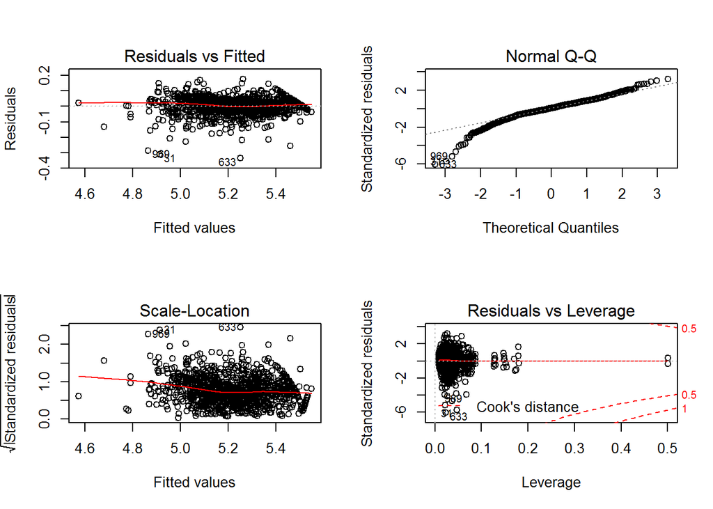

```r
par(mfrow = c(2,2))
plot(lm.step.1) # plot the AIC
```

```r
par(mfrow = c(1,1))
```

# Apply selected features from Step AIC to Linear Regression Model

```r
lm.model.2 = lm(LogPrice ~ LogLotArea + Bedroom + OverallCondition + LogArea +
                  Age + Quality + Neighborhood + Garage_area + bsmt_area,data = dataset1_trainingData)

summary(lm.model.2)
```

```
##
## Call:
## lm(formula = LogPrice ~ LogLotArea + Bedroom + OverallCondition +
##     LogArea + Age + Quality + Neighborhood + Garage_area + bsmt_area,
##     data = dataset1_trainingData)
##
## Residuals:
##      Min       1Q   Median       3Q      Max
## -0.33576 -0.02643  0.00251  0.03264  0.17697
##
## Coefficients:
##                       Estimate Std. Error t value Pr(>|t|)
## (Intercept)          3.332e+00  7.506e-02  44.388  < 2e-16 ***
## LogLotArea           8.046e-02  1.425e-02   5.647 2.14e-08 ***
## Bedroom             -8.111e-03  3.321e-03  -2.442 0.014772 *
## OverallCondition     2.135e-02  1.981e-03  10.775  < 2e-16 ***
## LogArea              3.870e-01  2.262e-02  17.107  < 2e-16 ***
## Age                 -8.249e-04  1.258e-04  -6.557 8.85e-11 ***
## Quality              2.853e-02  2.388e-03  11.947  < 2e-16 ***
## NeighborhoodBlueste -2.200e-02  4.311e-02  -0.510 0.609843
## NeighborhoodBrDale  -6.493e-02  2.266e-02  -2.865 0.004254 **
## NeighborhoodBrkSide -7.010e-02  1.959e-02  -3.578 0.000364 ***
## NeighborhoodClearCr  1.491e-02  2.153e-02   0.693 0.488711
## NeighborhoodCollgCr -3.516e-03  1.734e-02  -0.203 0.839390
## NeighborhoodCrawfor  8.576e-04  1.972e-02   0.043 0.965323
## NeighborhoodEdwards -5.868e-02  1.839e-02  -3.190 0.001466 **
## NeighborhoodGilbert  1.400e-03  1.866e-02   0.075 0.940196
## NeighborhoodIDOTRR  -1.428e-01  2.081e-02  -6.860 1.22e-11 ***
## NeighborhoodMeadowV -4.926e-02  2.696e-02  -1.828 0.067925 .
## NeighborhoodMitchel -3.847e-02  1.986e-02  -1.937 0.052999 .
## NeighborhoodNAmes   -4.204e-02  1.804e-02  -2.330 0.020003 *
## NeighborhoodNoRidge  2.903e-02  1.985e-02   1.462 0.143969
## NeighborhoodNPkVill -1.490e-02  2.539e-02  -0.587 0.557401
## NeighborhoodNridgHt  2.613e-02  1.781e-02   1.467 0.142655
## NeighborhoodNWAmes  -4.376e-02  1.890e-02  -2.316 0.020778 *
## NeighborhoodOldTown -1.179e-01  1.822e-02  -6.471 1.53e-10 ***
## NeighborhoodSawyer  -5.273e-02  1.939e-02  -2.720 0.006645 **
## NeighborhoodSawyerW -1.346e-02  1.853e-02  -0.726 0.467809
## NeighborhoodSomerst  2.514e-02  1.731e-02   1.452 0.146889
## NeighborhoodStoneBr  3.743e-02  2.094e-02   1.788 0.074102 .
## NeighborhoodSWISU   -6.575e-02  2.274e-02  -2.891 0.003918 **
## NeighborhoodTimber   1.518e-02  1.950e-02   0.779 0.436397
## NeighborhoodVeenker  2.540e-02  2.865e-02   0.886 0.375592
## Garage_area          1.126e-04  1.207e-05   9.334  < 2e-16 ***
## bsmt_area            7.234e-05  6.208e-06  11.653  < 2e-16 ***
## ---
## Signif. codes:  0 '***' 0.001 '**' 0.01 '*' 0.05 '.' 0.1 ' ' 1
##
## Residual standard error: 0.0562 on 988 degrees of freedom
## Multiple R-squared:  0.884,  Adjusted R-squared:  0.8803
## F-statistic: 235.4 on 32 and 988 DF,  p-value: < 2.2e-16
```

# Examine the Fit for the Final Linear Regression Model

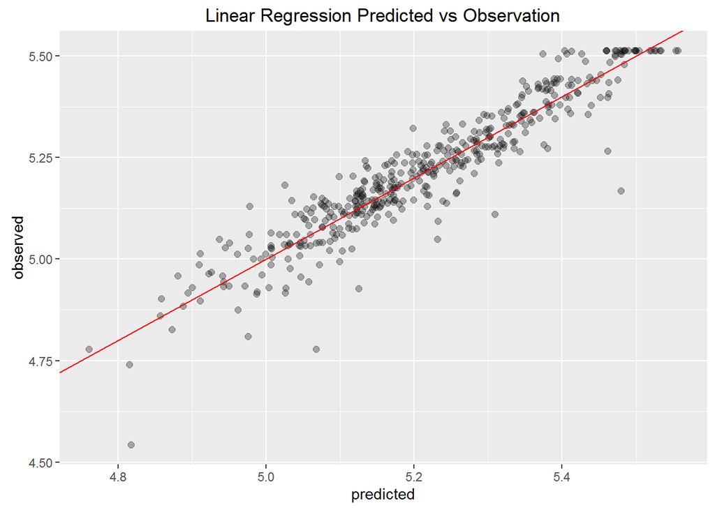

```r
## Examine the fit for the Linear Model 2 with the testing data

predict.lm.model.2 = predict(lm.model.2, newdata = dataset1_testingData)
df=data.frame(predicted = predict.lm.model.2, observed=dataset1_testingData[,'LogPrice'])
library(ggplot2)
ggplot(df, aes(x=predicted, y=observed)) +
  geom_point(size = 2, alpha = 0.3) +
  geom_abline(intercept = 0, slope = 1, colour = "red") +
  ggtitle("Linear Regression Predicted vs Observation")
```

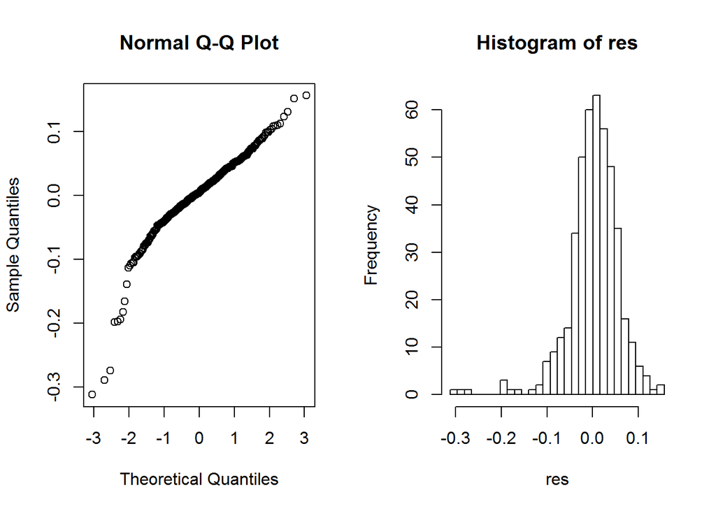

```r
predict.lm.model.test <- 10**predict.lm.model.2

## Examine the residuals for the Linear Model 2 with the testing data

res = dataset1_testingData[,'LogPrice'] - predict.lm.model.2
par(mfrow = c(1,2))
qqnorm(res)
breaks = seq(max(res), min(res), length.out = 31)
hist(res, breaks = breaks)
```

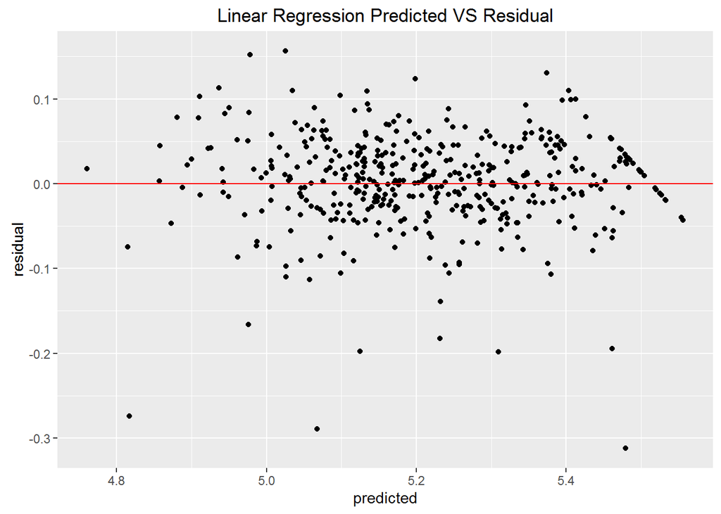

```r
df = data.frame(predicted = predict.lm.model.2, residual = res)
ggplot(df, aes(x = predicted, y = residual)) +
  geom_point() +
  geom_hline(yintercept = 0, colour = "red") +
  ggtitle("Linear Regression Predicted VS Residual")
```

```r
par(mfrow = c(1,1))
```

# Validate the same with test data and generate CSV

```r
LogPrice_test <- predict(lm.model.2, newdata = data_set_test)
SalePrice <- 10.0**LogPrice_test
Id_test <- dataset2_test$Id

Final_version <- data.frame(Id_test,SalePrice)

write.csv(Final_version, "Linear_Model.csv", row.names = T)
```

# Elastic Net Model

```r
enet_grid <- expand.grid(lambda = c(0, 0.01, .1),fraction = seq(.05, 1, length = 20))
set.seed(1234)
enet_model <-train(LogPrice ~ LogLotArea+Bedroom+OverallCondition+External_Quality+LogArea+Age+Quality
                   +Neighborhood+Garage_area+bsmt_area,
                   data = dataset1_trainingData,
                   method = "enet",
                   preProcess = c("center", "scale"),
                   tuneGrid = enet_grid,
                   trControl = trainControl(method= "cv"))
enet_model
```

```
## Elasticnet
##
## 1021 samples
##   10 predictor
##
## Pre-processing: centered (35), scaled (35)
## Resampling: Cross-Validated (10 fold)
## Summary of sample sizes: 919, 920, 919, 918, 918, 918, ...
## Resampling results across tuning parameters:
##
##   lambda  fraction  RMSE        Rsquared
##   0.00    0.05      0.14683660  0.6331575
##   0.00    0.10      0.13298319  0.6740456
##   0.00    0.15      0.12017708  0.7128581
##   0.00    0.20      0.10838397  0.7564822
##   0.00    0.25      0.09753656  0.7850020
##   0.00    0.30      0.08778332  0.8072881
##   0.00    0.35      0.07941334  0.8194932
##   0.00    0.40      0.07286762  0.8306199
##   0.00    0.45      0.06802939  0.8423057
##   0.00    0.50      0.06441036  0.8528479
##   0.00    0.55      0.06182169  0.8610193
##   0.00    0.60      0.06005456  0.8666452
##   0.00    0.65      0.05894324  0.8707270
##   0.00    0.70      0.05814459  0.8738083
##   0.00    0.75      0.05748763  0.8763863
##   0.00    0.80      0.05696303  0.8784752
##   0.00    0.85      0.05658918  0.8799562
##   0.00    0.90      0.05641973  0.8806350
##   0.00    0.95      0.05641043  0.8806571
##   0.00    1.00      0.05643613  0.8805139
##   0.01    0.05      0.14734474  0.6331575
##   0.01    0.10      0.13391770  0.6713628
##   0.01    0.15      0.12144099  0.7105618
##   0.01    0.20      0.10996817  0.7525630
##   0.01    0.25      0.09930876  0.7816653
##   0.01    0.30      0.08968284  0.8044666
##   0.01    0.35      0.08124242  0.8177441
##   0.01    0.40      0.07444203  0.8273821
##   0.01    0.45      0.06928954  0.8387546
```

[output cut: 19 more lines]

```
##   0.10    0.45      0.06984240  0.8341935
##   0.10    0.50      0.06608488  0.8435687
##   0.10    0.55      0.06331713  0.8520953
##   0.10    0.60      0.06135297  0.8595401
##   0.10    0.65      0.06007634  0.8648850
##   0.10    0.70      0.05918206  0.8691032
##   0.10    0.75      0.05853563  0.8725037
##   0.10    0.80      0.05809598  0.8751224
##   0.10    0.85      0.05781507  0.8770854
##   0.10    0.90      0.05767069  0.8784613
##   0.10    0.95      0.05762818  0.8794845
##   0.10    1.00      0.05767719  0.8801071
##
## RMSE was used to select the optimal model using  the smallest value.
## The final values used for the model were fraction = 0.95 and lambda = 0.
```

```r
enet_pred <- predict(enet_model, dataset1_testingData)
postResample(pred = enet_pred,  obs = dataset1_testingData$LogPrice)
```

```
##       RMSE   Rsquared
## 0.05558538 0.88664984
```

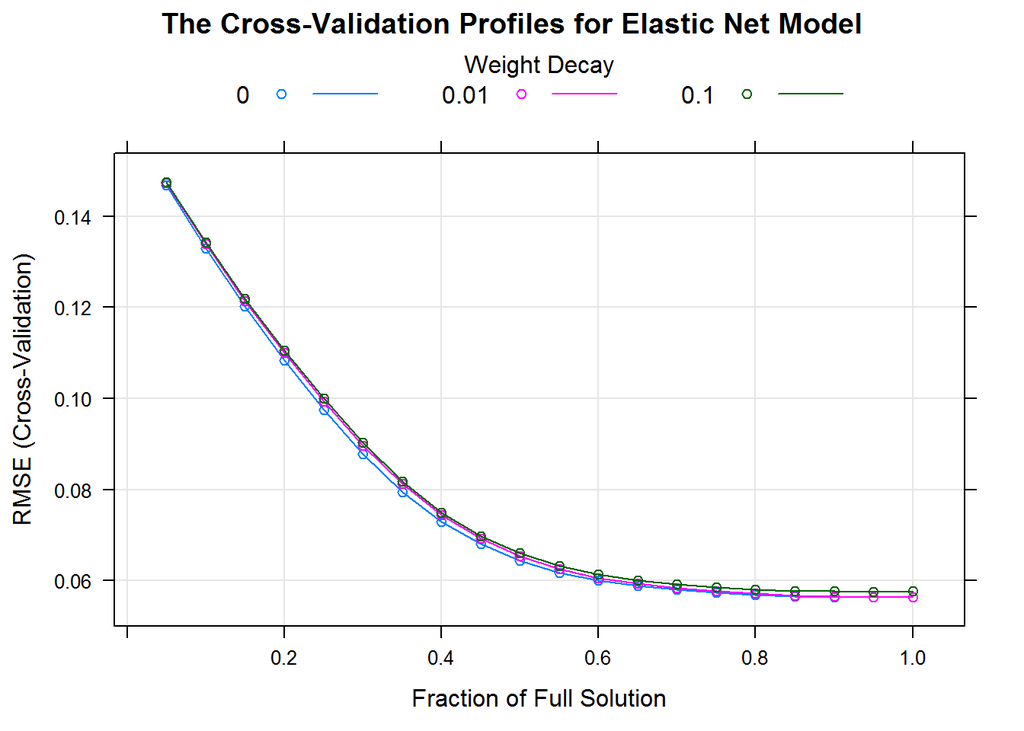

```r
update(plot(enet_model), main = "The Cross-Validation Profiles for Elastic Net Model")
```

RMSE is 0.055 , RMSE improved little bit in Elastic Net Model compared to linear Model.

# Predict saleprice for test data using Elastic Net Model

```r
enet_pred1 <- predict(enet_model, data_set_test)

Predicted_test <- 10**enet_pred1
write.csv(Predicted_test, "Elastic_Model.csv", row.names = T)
```

# Ridge Regression Model

```r
ridge_grid = expand.grid(lambda = seq(0, .1, length = 15))
set.seed(1234)
ridge.housing = train(LogPrice ~ LogLotArea+Bedroom+OverallCondition+External_Quality+LogArea+Age+Quality
                      +Neighborhood+Garage_area+bsmt_area,
                      data = dataset1_trainingData,
                      method = "ridge",
                      preProcess = c("center", "scale"),
                      tuneGrid = ridge_grid,
                      trControl = trainControl(method= "cv"))
ridge.housing
```

```
## Ridge Regression
##
## 1021 samples
##   10 predictor
##
## Pre-processing: centered (35), scaled (35)
## Resampling: Cross-Validated (10 fold)
## Summary of sample sizes: 919, 920, 919, 918, 918, 918, ...
## Resampling results across tuning parameters:
##
##   lambda       RMSE        Rsquared
##   0.000000000  0.05643613  0.8805139
##   0.007142857  0.05640933  0.8807390
##   0.014285714  0.05642123  0.8808277
##   0.021428571  0.05645326  0.8808662
##   0.028571429  0.05650148  0.8808732
##   0.035714286  0.05656428  0.8808564
##   0.042857143  0.05664070  0.8808203
##   0.050000000  0.05673003  0.8807681
##   0.057142857  0.05683170  0.8807022
##   0.064285714  0.05694524  0.8806244
##   0.071428571  0.05707021  0.8805365
##   0.078571429  0.05720622  0.8804398
##   0.085714286  0.05735294  0.8803353
##   0.092857143  0.05751003  0.8802241
##   0.100000000  0.05767719  0.8801071
##
## RMSE was used to select the optimal model using  the smallest value.
## The final value used for the model was lambda = 0.007142857.
```

RMSE for Ridge Regression is 0.056

# Examine the fit for ridge regression model

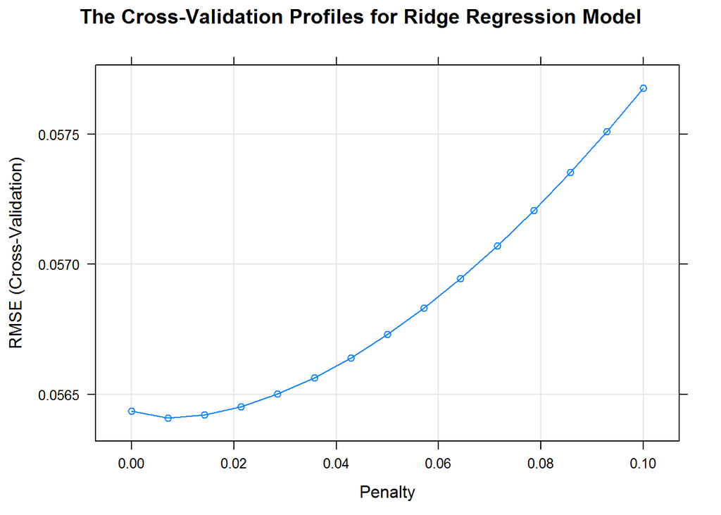

```r
predict.ridge.housing = predict(ridge.housing, newdata = dataset1_testingData)

update(plot(ridge.housing), xlab = "Penalty",main = "The Cross-Validation Profiles for Ridge Regression Model")
```

```r
postResample(pred = predict.ridge.housing,  obs = dataset1_testingData$LogPrice)
```

```
##       RMSE   Rsquared
## 0.05568339 0.88634658
```

```r
# Examine the fit for ridge regression model using test data

predict.ridge.housing1 = predict(ridge.housing, newdata = data_set_test)

Predicted_ridge <- 10**predict.ridge.housing1
write.csv(Predicted_ridge, "Ridge_Regression_Model.csv", row.names = T)
```

# Random Forest Regression Model

```r
# # Random Forest Train and fit the model

fit <- randomForest(LogPrice ~ LogLotArea+Bedroom+OverallCondition+External_Quality+LogArea+Age+Quality
                    +Neighborhood+Garage_area+bsmt_area, data=dataset1_trainingData)
# summarize the fit
summary(fit)
```

```r
# # # make predictions with Random Forest  model


predictions <- predict(fit, dataset1_testingData)
# summarize accuracy
rmse <- sqrt(mean((dataset1_testingData$LogPrice - predictions)^2))
print(rmse)
```

```
## [1] 0.05929512
```

```r
# Predict SalePrice using Test data

predictions_Random_forest <- predict(fit, data_set_test)
Predicted_random_forest <- 10**predictions_Random_forest
write.csv(Predicted_random_forest, "Random_Forest_Model.csv", row.names = T)
```

RMSE for Random Forest Regression Model with selected features is 0.059

# SVM Regression Model

```r
# fit model
fit <- ksvm(LogPrice ~ LogLotArea+Bedroom+OverallCondition+External_Quality+LogArea+Age+Quality
            +Neighborhood+Garage_area+bsmt_area, dataset1_trainingData)
# summarize the fit
summary(fit)
# make predictions
predictions <- predict(fit, dataset1_testingData)
# summarize accuracy
rmse <- sqrt(mean((dataset1_testingData$LogPrice - predictions)^2))
print(rmse)
```

```r
# make predictions
predictions <- predict(fit, dataset1_testingData)
# summarize accuracy
rmse <- sqrt(mean((dataset1_testingData$LogPrice - predictions)^2))
print(rmse)
```

```
## [1] 0.05712577
```

```r
# predict SalePrice using Test Data
predictions_svm <- predict(fit, data_set_test)
Predicted_svm <- 10**predictions_Random_forest
write.csv(Predicted_svm, "SVM_Model.csv", row.names = T)
```

RMSE for SVM Regression Model with selected features is 0.057

# Conclusion